# Week 9: Assignment 8, Part 1

Your names

In the part of the assignment, you will create a sqlite database from nycflights13, and answer questions using the database.

### Install the package

```r
install.packages("nycflights13")
```

### Load the package

```r
library(nycflights13)
library(tidyverse, quietly = TRUE)
```

### Import the data into a database (2 points)

There are five datasets in this database. Import the data into an sqlite database

```r
library(DBI)
db <- dbConnect(RSQLite::SQLite(), file = "~/Data/my472/nycflight13.sqlite" )

dbWriteTable(db, 'airlines', airlines)
dbWriteTable(db, 'airports', airports)
dbWriteTable(db, 'flights', flights)
dbWriteTable(db, 'planes', planes)
dbWriteTable(db, 'weather', weather)
```

### Check the data (3 points)

Using `nrow()` and `dbGetQuery()`, check whether the numbers of the rows in the original dataset and the table match.

```r
as.vector(nrow(airlines) == dbGetQuery(db, "SELECT COUNT(*) FROM airlines"))
```

```
## [1] TRUE
```

```r
as.vector(nrow(airports) == dbGetQuery(db, "SELECT COUNT(*) FROM airports"))
```

```
## [1] TRUE
```

```r
as.vector(nrow(flights) == dbGetQuery(db, "SELECT COUNT(*) FROM flights"))
```

```
## [1] TRUE
```

```r
as.vector(nrow(planes) == dbGetQuery(db, "SELECT COUNT(*) FROM planes"))
```

```
## [1] TRUE
```

```r
as.vector(nrow(weather) == dbGetQuery(db, "SELECT COUNT(*) FROM weather"))
```

```
## [1] TRUE
```

## Flight delays (15 points)

Now, we are going to check the number of flights with significant delays.

Answer the following questions. (For each question, a full-mark is three points. If you reached the answer in one query, you get 3 points. If the answer is collect but needed run more thann one queries, you get 2).

```r
table(flights$origin)
```

```
##
##    EWR    JFK    LGA
## 120835 111279 104662
```

```r
#1. Number of flights with more than two hours of delay
q <- "SELECT COUNT(*) FROM flights WHERE dep_delay > 120"
dbGetQuery(db, q)
```

```
##   COUNT(*)
## 1     9723
```

```r
#2. Number of flights with more than two hours of departure delay by month and origin airport
#3. Percentage of flights with more than two hours of delay by month and origin airport (HINT `CASE WHEN`)
q <- "SELECT origin, month, COUNT(CASE WHEN dep_delay > 120 THEN '1' ELSE null END) AS sig_delay,
COUNT(*) AS total_flight, COUNT(CASE WHEN dep_delay > 120 THEN '1' ELSE null END) * 1.0 / COUNT(*) AS delay_prop
FROM flights
GROUP BY month, origin
ORDER BY origin, month"
dbGetQuery(db, q)
```

```
##    origin month sig_delay total_flight  delay_prop
## 1     EWR     1       301         9893 0.030425553
## 2     EWR     2       245         9107 0.026902383
## 3     EWR     3       385        10420 0.036948177
## 4     EWR     4       419        10531 0.039787295
## 5     EWR     5       291        10592 0.027473565
## 6     EWR     6       540        10175 0.053071253
## 7     EWR     7       519        10475 0.049546539
## 8     EWR     8       275        10359 0.026546964
## 9     EWR     9       210         9550 0.021989529
## 10    EWR    10       206        10104 0.020387965
## 11    EWR    11       113         9707 0.011641084
## 12    EWR    12       380         9922 0.038298730
## 13    JFK     1       183         9161 0.019975985
## 14    JFK     2       199         8421 0.023631398
```

[output cut: 22 more lines]

```r
#4. Percentage of flights with more than two hours of delay by airline (use airlines' full names (Example: American Airlines Inc.))
q <- "SELECT a.carrier, a.name, COUNT(CASE WHEN dep_delay > 120 THEN '1' ELSE null END) AS sig_delay,
COUNT(*) AS total_flight, COUNT(CASE WHEN dep_delay > 120 THEN '1' ELSE null END) * 1.0 / COUNT(*) AS delay_prop
FROM flights AS f
JOIN airlines AS a ON a.carrier = f.carrier
GROUP BY a.carrier
ORDER BY delay_prop DESC"
dbGetQuery(db, q)
```

```
##    carrier                        name sig_delay total_flight delay_prop
## 1       OO       SkyWest Airlines Inc.         2           32 0.06250000
## 2       F9      Frontier Airlines Inc.        34          685 0.04963504
## 3       FL AirTran Airways Corporation       151         3260 0.04631902
## 4       EV    ExpressJet Airlines Inc.      2443        54173 0.04509627
## 5       9E           Endeavor Air Inc.       772        18460 0.04182015
## 6       YV          Mesa Airlines Inc.        23          601 0.03826955
## 7       WN      Southwest Airlines Co.       452        12275 0.03682281
## 8       VX              Virgin America       181         5162 0.03506393
## 9       B6             JetBlue Airways      1621        54635 0.02966963
## 10      AS        Alaska Airlines Inc.        17          714 0.02380952
## 11      UA       United Air Lines Inc.      1364        58665 0.02325066
## 12      MQ                   Envoy Air       607        26397 0.02299504
## 13      DL        Delta Air Lines Inc.      1093        48110 0.02271877
## 14      AA      American Airlines Inc.       720        32729 0.02199884
## 15      HA      Hawaiian Airlines Inc.         5          342 0.01461988
## 16      US             US Airways Inc.       238        20536 0.01158940
```

```r
#5. (continued from #4) Which airlines with more than 10,000 flights has the lowest percentage in departure delay and what's the percentage? (HINT: `HAVING`)
q <- "SELECT a.carrier, a.name, COUNT(CASE WHEN dep_delay > 120 THEN '1' ELSE null END) AS sig_delay,
COUNT(*) AS total_flight, COUNT(CASE WHEN dep_delay > 120 THEN '1' ELSE null END) * 1.0 / COUNT(*) AS delay_prop
FROM flights AS f
JOIN airlines AS a ON a.carrier = f.carrier
GROUP BY a.carrier
HAVING COUNT(*) > 10000
ORDER BY delay_prop"
dbGetQuery(db, q)
```

```
##   carrier                     name sig_delay total_flight delay_prop
## 1      US          US Airways Inc.       238        20536 0.01158940
## 2      AA   American Airlines Inc.       720        32729 0.02199884
## 3      DL     Delta Air Lines Inc.      1093        48110 0.02271877
## 4      MQ                Envoy Air       607        26397 0.02299504
## 5      UA    United Air Lines Inc.      1364        58665 0.02325066
## 6      B6          JetBlue Airways      1621        54635 0.02966963
## 7      WN   Southwest Airlines Co.       452        12275 0.03682281
## 8      9E        Endeavor Air Inc.       772        18460 0.04182015
## 9      EV ExpressJet Airlines Inc.      2443        54173 0.04509627
```

## Flight delays and airplane (8 points)

Using two tables, explore the relations between departure delays and ages of airplanes. Are there any relations? Provide the reasoning that leads to your argument, and at least one figure to support the argument.

```r
q <- "
SELECT p.tailnum, p.year, dep_delay
FROM flights f JOIN planes p ON p.tailnum = f.tailnum"
dat <- dbGetQuery(db, q)
cor(dat$dep_delay, dat$year, use = "complete.obs")
```

```
## [1] 0.01535396
```

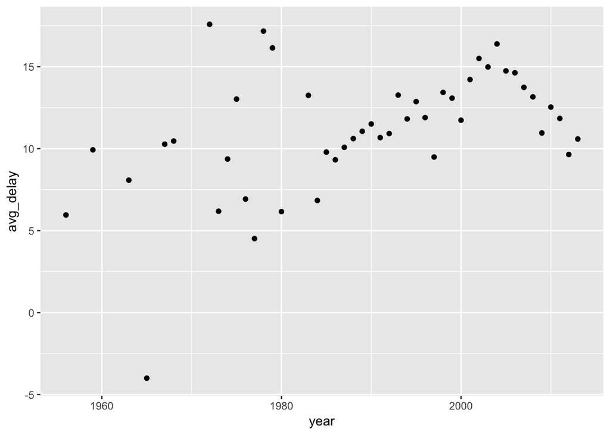

```r
dat %>%
  group_by(year) %>%
  summarize(avg_delay = mean(dep_delay, na.rm = T)) %>%
  ggplot(aes(x = year, y = avg_delay)) + geom_point()
```

*From the figure, the relation is not immedaitely clear, but by assuming curve liner relations, we can find the relations between year and the delay.*

```r
suppressMessages(library(stargazer))
lm(dep_delay ~ poly(year, 3), data = dat%>% filter(!is.na(year))) %>% stargazer(type = "html")
```

|  | *Dependent variable:* |
| --- | --- |
|  | dep_delay |
| poly(year, 3)1 | 331.263*** |
|  | (40.785) |
| poly(year, 3)2 | -442.475*** |
|  | (41.014) |
| poly(year, 3)3 | -487.500*** |
|  | (40.960) |
| Constant | 13.183*** |
|  | (0.077) |
| Observations | 274,796 |
| R<sup>2</sup> | 0.001 |
| Adjusted R<sup>2</sup> | 0.001 |
| Residual Std. Error | 40.544 (df = 274792) |
| F Statistic | 108.389*** (df = 3; 274792) |
| *Note:* | p<0.1; p<0.05; p<0.01 |

*Or if I run the regression with the summary data:*

```r
dat %>%
  group_by(year) %>%
  summarize(avg_delay = mean(dep_delay, na.rm = T)) -> tmp
lm(avg_delay ~ year, data = (tmp %>% filter(complete.cases(.))))  %>% stargazer(type = "html")
```

|  | *Dependent variable:* |
| --- | --- |
|  | avg_delay |
| year | 0.114*** |
|  | (0.033) |
| Constant | -214.873*** |
|  | (65.507) |
| Observations | 46 |
| R<sup>2</sup> | 0.213 |
| Adjusted R<sup>2</sup> | 0.195 |
| Residual Std. Error | 3.412 (df = 44) |
| F Statistic | 11.904*** (df = 1; 44) |
| *Note:* | p<0.1; p<0.05; p<0.01 |

## Flight delays and weather (7 points)

Explore the relations between departure delay and weather. Are there any relations?

```r
library(nycflights13)
weather %>% head()
```

```
## # A tibble: 6 x 15
##   origin  year month   day  hour  temp  dewp humid wind_dir wind_speed
##   <chr>  <dbl> <dbl> <int> <int> <dbl> <dbl> <dbl>    <dbl>      <dbl>
## 1 EWR     2013     1     1     1  39.0  26.1  59.4      270      10.4
## 2 EWR     2013     1     1     2  39.0  27.0  61.6      250       8.06
## 3 EWR     2013     1     1     3  39.0  28.0  64.4      240      11.5
## 4 EWR     2013     1     1     4  39.9  28.0  62.2      250      12.7
## 5 EWR     2013     1     1     5  39.0  28.0  64.4      260      12.7
## 6 EWR     2013     1     1     6  37.9  28.0  67.2      240      11.5
## # ... with 5 more variables: wind_gust <dbl>, precip <dbl>,
## #   pressure <dbl>, visib <dbl>, time_hour <dttm>
```

```r
# merge tables
flight_weather <- dbGetQuery(db, "
SELECT tailnum, dep_delay, w.* FROM flights AS f
JOIN weather AS w ON w.origin = f.origin AND
w.month = f.month AND
w.day = f.day AND
w.hour = f.hour")

# calculate averages for the variables of interest
flight_weather_avg <- flight_weather %>%
  group_by(origin, month, day, hour) %>%
  summarise_at(.vars = c(2, 8:10, 12:16), .funs = mean) %>%
  ungroup()
```

#### Check the correlations

```r
flight_weather_avg %>% select(dep_delay:visib) %>%
  cor(use = "pairwise.complete.obs") %>% round(3) %>% knitr::kable()
```

|  | dep_delay | temp | dewp | humid | wind_speed | wind_gust | precip | pressure | visib |
| --- | --- | --- | --- | --- | --- | --- | --- | --- | --- |
| dep_delay | 1.000 | 0.072 | 0.105 | 0.109 | 0.084 | 0.084 | 0.112 | -0.146 | -0.104 |
| temp | 0.072 | 1.000 | 0.886 | 0.048 | -0.158 | -0.329 | 0.009 | -0.249 | 0.098 |
| dewp | 0.105 | 0.886 | 1.000 | 0.497 | -0.235 | -0.276 | 0.096 | -0.282 | -0.125 |
| humid | 0.109 | 0.048 | 0.497 | 1.000 | -0.206 | 0.053 | 0.229 | -0.163 | -0.538 |
| wind_speed | 0.084 | -0.158 | -0.235 | -0.206 | 1.000 | 0.883 | 0.049 | -0.211 | 0.046 |
| wind_gust | 0.084 | -0.329 | -0.276 | 0.053 | 0.883 | 1.000 | 0.069 | -0.237 | -0.143 |
| precip | 0.112 | 0.009 | 0.096 | 0.229 | 0.049 | 0.069 | 1.000 | -0.085 | -0.313 |
| pressure | -0.146 | -0.249 | -0.282 | -0.163 | -0.211 | -0.237 | -0.085 | 1.000 | 0.108 |
| visib | -0.104 | 0.098 | -0.125 | -0.538 | 0.046 | -0.143 | -0.313 | 0.108 | 1.000 |

#### Or using corrplot package

*As you see, many of the weather variables have relations with the delay in the expected direction*

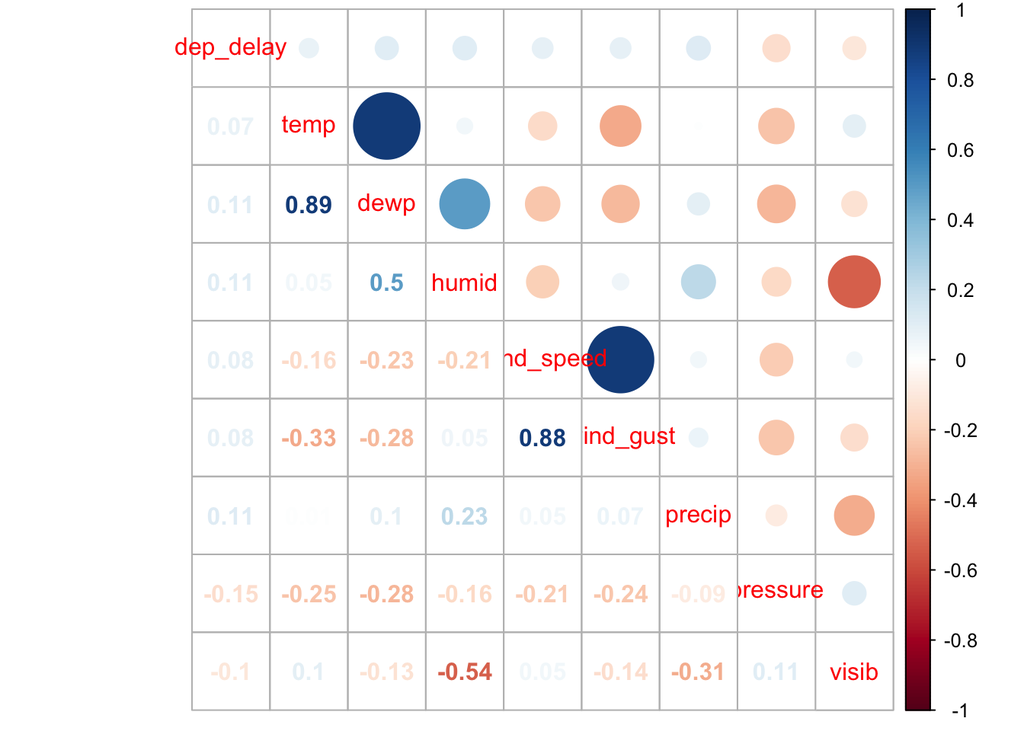

```r
library(corrplot)
flight_weather_avg %>% select(dep_delay:visib) %>%
  cor(use = "pairwise.complete.obs") %>% corrplot.mixed()
```

#### regression analysis

```r
lm(dep_delay ~ ., data = flight_weather_avg %>% select(dep_delay:visib)) %>%
  stargazer(type = 'html')
```

|  | *Dependent variable:* |
| --- | --- |
|  | dep_delay |
| temp | 0.285* |
|  | (0.148) |
| dewp | -0.268 |
|  | (0.163) |
| humid | 0.205** |
|  | (0.092) |
| wind_speed | -0.036 |
|  | (0.101) |
| wind_gust | 0.192** |
|  | (0.089) |
| precip | 16.493 |
|  | (23.282) |
| pressure | -0.140*** |
|  | (0.037) |
| visib | -0.616* |
|  | (0.345) |
| Constant | 137.352*** |
|  | (40.038) |
| Observations | 3,345 |
| R<sup>2</sup> | 0.029 |
| Adjusted R<sup>2</sup> | 0.027 |
| Residual Std. Error | 13.656 (df = 3336) |
| F Statistic | 12.630*** (df = 8; 3336) |
| *Note:* | p<0.1; p<0.05; p<0.01 |

#### standardized regression

```r
lm(dep_delay ~ ., data = flight_weather_avg %>%
     mutate_at(.vars = vars(temp:visib), .funs = scale) %>%
     select(dep_delay:visib)) %>%
  stargazer(type = 'html')
```

|  | *Dependent variable:* |
| --- | --- |
|  | dep_delay |
| temp | 5.114* |
|  | (2.651) |
| dewp | -5.209 |
|  | (3.166) |
| humid | 4.025** |
|  | (1.801) |
| wind_speed | -0.202 |
|  | (0.564) |
| wind_gust | 1.147** |
|  | (0.530) |
| precip | 0.492 |
|  | (0.695) |
| pressure | -1.046*** |
|  | (0.278) |
| visib | -1.252* |
|  | (0.701) |
| Constant | 10.548*** |
|  | (0.711) |
| Observations | 3,345 |
| R<sup>2</sup> | 0.029 |
| Adjusted R<sup>2</sup> | 0.027 |
| Residual Std. Error | 13.656 (df = 3336) |
| F Statistic | 12.630*** (df = 8; 3336) |
| *Note:* | p<0.1; p<0.05; p<0.01 |

*Coefficients for many of variables are significant in the expected direction*